# Introduction to Saanich and R/RStudio

version October 15, 2019

## Module outline

- Oct 15: Introduction to Saanich Inlet data and R/RStudio and working with data in the R tidyverse Part 1
- Oct 17: Data in the R tidyverse Part 2 and ggplot plotting

## Learning objectives

- Describe the Saanich Inlet system
- Identify uses of R/RStudio in bioinformatics

## Saanich Inlet

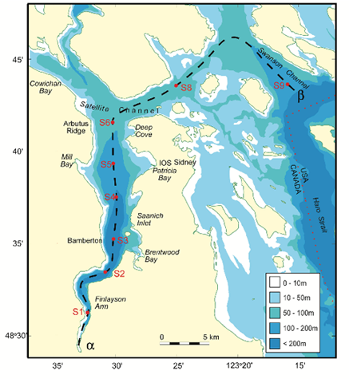

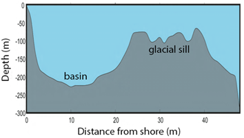

## Geochemical gradients

### Oxygen example

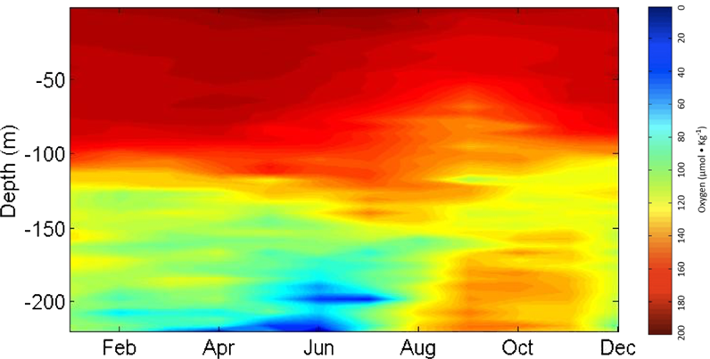

## Seasonal cycles

### Oxygen example

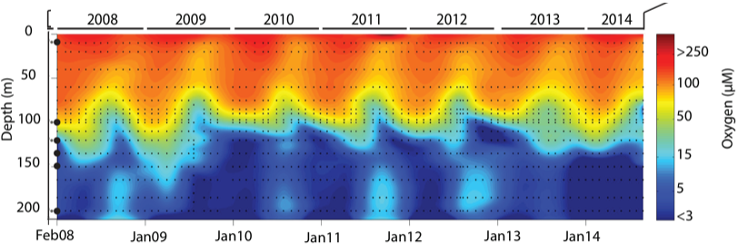

## More on Saanich

- **More details and microbial data to come in Project 2!**
- See references under Project 2 on Canvas
  - **Overview**: Hallam SJ *et al*. [10.1038/sdata.2017.158](https://www.nature.com/articles/sdata2017158)
  - **Geochemistry**: Torres-Beltrán M *et al*. [10.1038/sdata.2017.159](https://www.nature.com/articles/sdata2017159)
  - **Microbes**: Hawley AK *et al*. [10.1038/sdata.2017.160](https://www.nature.com/articles/sdata2017160)

Switching gears…

## Why [R](https://cran.rproject.org/)?

- Open source
- Reproducible research
- Huge community of developers around the world
- Custom packages
  - 13,242 on [CRAN](https://cran.rproject.org/web/packages/available_packages_by_name.html)
  - 1,562 on [Bioconductor](https://www.bioconductor.org/packages)
  - More on individual GitHub accounts

## Why [RStudio](https://www.rstudio.com/)?

Integrated development environment (IDE) for R

- User friendly (particularly for novices)
- Customizable visual interface
- Integrated file, package, and plot management
- Downloaded help pages
- Integration with other data science resources like Git/GitHub, Shiny apps, etc.

## A tour of RStudio

[figure not shown]